# Verkefni 1

Brynjar Mar (bmb23), Kári Einarsson (kae44) og Indriði Már Indriðason (imi2)

2024-02-29

```r
library(tidyverse)
library(ggplot2)
library(scales)
library(knitr)
```

# Hluti 1 - Gagnamöndl (30 %)

## a)

Lesið gagnasafnið inn í R/RStudio með skipuninni hér að neðan og geymið í hlut sem ber upphafsstafi þeirra sem verkefnið vinna (ef Gréta Halldórsdóttir og Sigurður Karl Jónsson eru að vinna saman skulu þau nefna hlutinn gs).

nafn_a_hlut <- read_csv2(“https://ahj.hi.is/kaupskra.csv”, locale = locale(encoding = “ISO8859-1”))

þar sem þið skiptið nafn_a_hlut út fyrir upphafsstafina (þó skal ekki nota íslenska stafi).

```r
bik <- read_csv2("https://ahj.hi.is/kaupskra.csv", locale = locale(encoding = "ISO8859-1"))
```

medaltal taknad med $\mu$

## b)

Notið filter() skipunina til að velja fullbúnar eignir (sjá fullbuid breytuna) sem eru “Fjolbyli” og “Serbyli” og byggja á samningum sem eru er nothæfir. Yfirskrifið stóra gagnaramman í a) lið með þessum eignum.

```r
tegund_inni <- c("Serbyli", "Fjolbyli")
bik <- filter(bik, fullbuid==1, tegund%in%tegund_inni, onothaefur_samningur==0)
```

## c)

Búið til nýja breytu í gagnarammanum ykkar sem inniheldur fermetraverð eignanna, nefnið breytuna fermetraverd.

```r
bik <- mutate(bik, fermetraverd=kaupverd/einflm)
```

## d)

Búið til nýja breytu í gagnarammanum ykkar sem inniheldur árið sem eignin var seld, nefnið breytuna ar (t.d. með að nota year() fallið í lubridate pakkanum).

```r
bik <- mutate(bik, ar=year(utgdag))
```

## e)

Veljið ykkur þrjú póstnúmer til að vinna með. Það þurfa að vera a.m.k. 200 sérbýli í hverju póstúmeri fyrir sig. Yfirskrifið gagnaramman í b) lið með eignum úr þessum þremur póstnúmerum. Þið skulið nota þennan gagnaramma í verkefninu.

```r
pnr <- c(107, 105, 210)
bik <- filter(bik, postnr%in%pnr)
```

## f)

Kannið gerð breytanna í gagnarammanum ykkar og breytið ef þarf.

```r
bik <- mutate(bik, emnr = factor(emnr))
bik <- mutate(bik, postnr = factor(postnr))
```

# Hluti 2 - Myndræn Framsetning (30%)

## g)

Teiknið mynd sem sýnir stærð eignanna í rammanum ykkar (það eiga ekki að vera aðrar breytur á myndinni). Eru einhverjir gagnapunktar sem koma í ljós sem mögulega þarf að skoða sérstaklega? Ef svo er skulið þið gera það.

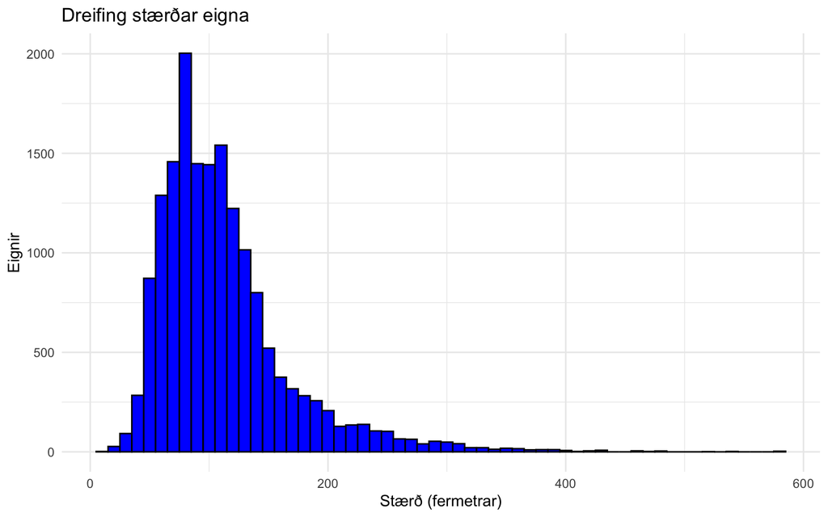

```r
staerdeigna <- ggplot(bik, aes(x=einflm)) +
  geom_histogram(binwidth = 10, fill="blue", color="black") + # Binwidth gæti þurft aðlögun
  xlab('Stærð (fermetrar)') +
  ylab('Eignir') +
  ggtitle('Dreifing stærðar eigna') +
  theme_minimal()

staerdeigna
```

## h)

Teiknið mynd sem sýnir fjölda eigna eftir póstnúmerum og tegundum eigna á sömu mynd (sérbýli eða fjölbýli).

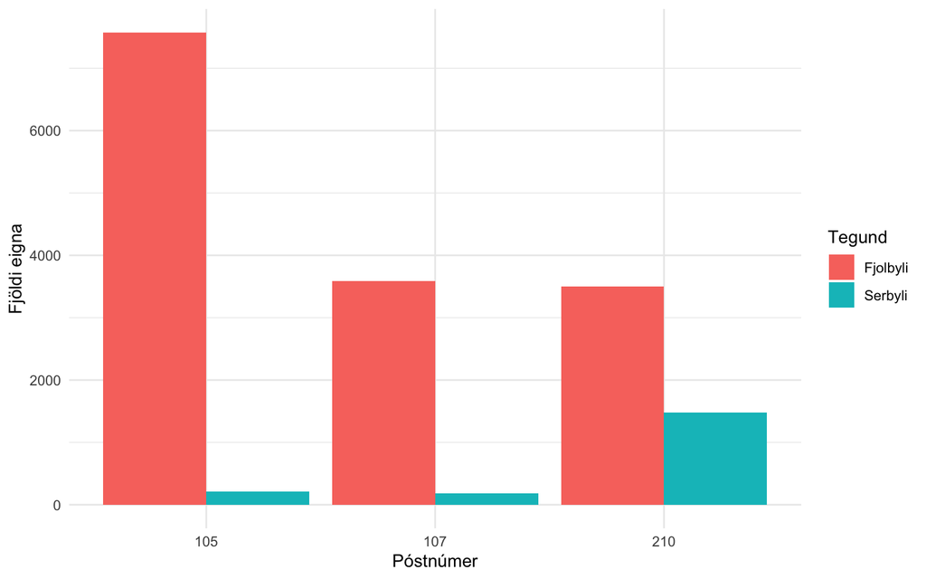

```r
postnrtegund <- ggplot(bik, aes(x=postnr, fill=tegund)) +
  geom_bar(position='dodge') + # Nota sjálfgefið stat="count" til að telja tilvik
  xlab('Póstnúmer') +
  ylab('Fjöldi eigna') +
  labs(fill='Tegund') + # Merkja fyllingarbreytuna sem tegund eignar
  theme_minimal()

postnrtegund
```

## i)

Teiknið mynd sem sýnir stærð eignanna eftir póstnúmeri.

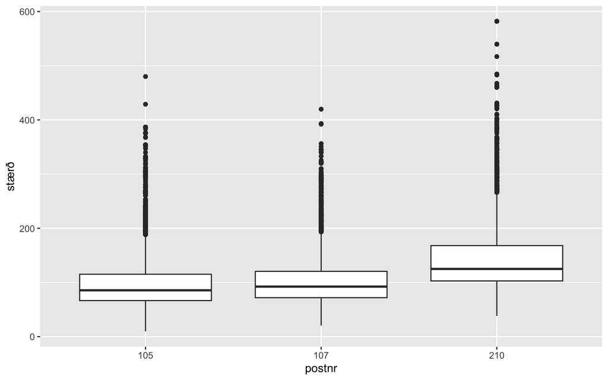

```r
postnrstaerd <- ggplot(bik,aes(x=postnr, y=einflm)) + geom_boxplot() + xlab('postnr') + ylab('stærð')
postnrstaerd
```

## j)

Teiknið mynd sem sýnir samband stærðar og kaupverðs fyrir hvert póstnúmer fyrir sig (notið t.d. facet_grid til að skipta myndinni upp eftir póstnúmerum). Notið mismunadi liti til að sýna hvaða ár eignirnar voru keyptar. Eru einhverjir gagnapunktar sem koma í ljós sem mögulega þarf að skoða sérstaklega? Ef svo er skulið þið gera það.

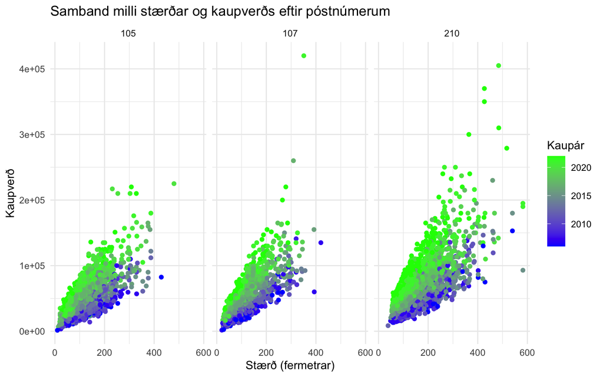

```r
ggplot(bik, aes(x=einflm, y=kaupverd, color=ar)) +
  geom_point() +  # Notar punkta til að sýna hvert gagnapar
  facet_grid(~ postnr) +  # Skiptir myndinni upp eftir póstnúmerum
  scale_color_gradient(low="blue", high="green") +  # Breytir litaskala fyrir kaupár
  labs(x="Stærð (fermetrar)", y="Kaupverð", color="Kaupár") +
  theme_minimal() +
  ggtitle("Samband milli stærðar og kaupverðs eftir póstnúmerum")
```

# Hluti 3- Töflur (20%)

## k)

Búið til töflu sem sýnir fjölda eigna í póstnúmerunum þremur eftir gerð eigna (sérbýli eða fjölbýli).

```r
# Búum til töflu sem sýnir fjölda eigna í hverju póstnúmeri eftir gerð eigna
taflak <- bik %>%
  group_by(postnr, tegund) %>%  # Hópum gögnin eftir póstnúmeri og gerð eigna
  summarise(fjoldi = n(), .groups = 'drop')  # Teljum fjölda eigna í hverjum hóp

# Prentum út töfluna
print(taflak)
```

```
## # A tibble: 6 × 3
##   postnr tegund   fjoldi
##   <fct>  <chr>     <int>
## 1 105    Fjolbyli   7575
## 2 105    Serbyli     208
## 3 107    Fjolbyli   3592
## 4 107    Serbyli     184
## 5 210    Fjolbyli   3499
## 6 210    Serbyli    1478
```

## l)

Búið til töflu sem sýnir hlutfall sérbýla og fjölbýla í póstnúmerunum þremur. Það á s.s. að vera hægt að lesa hvert hlutfall sérbýla og fjölbýla er í hverju póstnúmeri fyrir sig.

```r
tafla <- bik %>%
  filter(postnr %in% c(105, 107, 210)) %>%  # Filter for the desired postal codes
  group_by(postnr, tegund) %>%
  summarise(fjoldi = n(), .groups = 'drop') %>%  # Count occurrences of each 'tegund' within 'postnr'
  group_by(postnr) %>%
  mutate(total = sum(fjoldi)) %>%  # Calculate total count per 'postnr'
  mutate(hlutfall = round(fjoldi / total * 100, 1)) %>%  # Calculate the percentage and round to 1 decimal place
  ungroup() %>%
  mutate(hlutfall = paste0(hlutfall, "%")) %>%  # Append '%' sign
  select(-fjoldi, -total) %>%
  pivot_wider(names_from = tegund, values_from = hlutfall)  # Reshape the data

# Print the corrected table
print(tafla)
```

```
## # A tibble: 3 × 3
##   postnr Fjolbyli Serbyli
##   <fct>  <chr>    <chr>
## 1 105    97.3%    2.7%
## 2 107    95.1%    4.9%
## 3 210    70.3%    29.7%
```

## m)

Búið til töflu sem sýnir meðaltal, miðgildi og staðalfrávik fermetraverðs skipt upp eftir ári, póstnúmeri og tegund eigna (sérbýli eða fjölbýli). Sýnið einnig fjölda eigna sem lenda í hverjum flokki í töflunni. Það á t.d. að vera hægt að lesa hvert meðalfermetraverð eigna í sérbýli var árið 2021 í hverju póstnúmeri fyrir sig og hversu margir kaupsamingar eru að baki.

```r
tolfraedi_tabla <- bik %>%
  group_by(ar, postnr, tegund) %>%
  summarise(
    Medaltal = mean(fermetraverd, na.rm = TRUE),
    Midgildi = median(fermetraverd, na.rm = TRUE),
    Stadalfravik = sd(fermetraverd, na.rm = TRUE),
    Fjoldi = n(),
    .groups = 'drop'
  )
tolfraedi_tabla
```

```
## # A tibble: 102 × 7
##       ar postnr tegund   Medaltal Midgildi Stadalfravik Fjoldi
##    <dbl> <fct>  <chr>       <dbl>    <dbl>        <dbl>  <int>
##  1  2006 105    Fjolbyli     234.     225.         51.1    276
##  2  2006 105    Serbyli      203.     201.         27.7      8
##  3  2006 107    Fjolbyli     236.     238.         40.3    142
##  4  2006 107    Serbyli      273.     268.         45.8      6
##  5  2006 210    Fjolbyli     252.     257.         44.2     65
##  6  2006 210    Serbyli      241.     240.         35.8     47
##  7  2007 105    Fjolbyli     261.     254.         47.1    646
##  8  2007 105    Serbyli      251.     222.         63.4     22
##  9  2007 107    Fjolbyli     267.     266.         49.2    334
## 10  2007 107    Serbyli      291.     291.         62.6     19
## # ℹ 92 more rows
```

# Hluti 4 - Líkindafræði (10%)

## n)

Gerum nú ráð fyrir að við séum að vinna með hverfi á stórreykjavíkursvæðinu þar sem 20% eigna eru einbýlishús. Hugsum okkur nú að við veljum 3 eignir í hverfinu af handahófi.

### i)

Hverjar eru líkurnar á að ein eignin sé einbýlishús?  
a) ef það má bara vera ein og ekki fleiri

```r
dbinom(1,3,0.2)
```

```
## [1] 0.384
```

b) ef það mega vera fleiri en ein

```r
1-pbinom(0,3,0.2)
```

```
## [1] 0.488
```

### ii)

Hverjar eru líkurnar á að fleiri en ein eign séu einbýlishús?

```r
1-pbinom(1,3,0.2)
```

```
## [1] 0.104
```

## o)

Gerum nú ráð fyrir að stærð einbýlishúsa í hverfinu fylgi normaldreifingu með meðaltal 170 fm og staðalfrávik 20 fm.

### i)

Sé eign úr hverfinu valin af handahófi, hverjar eru líkurnar á að hún sé stærri en 180 fm?

```r
pnorm(180,170,20)
```

```
## [1] 0.6914625
```

### ii)

Jonni ætlar að byggja einbýlishús í hverfinu og vill endilega að það verði í hópi 5% stærstu einbýlishúsanna í hverfinu. Hvað þarf húsið að verða stórt?

```r
qnorm(0.95,170,20)
```

```
## [1] 202.8971
```